# Serum analysis

2022-12-21

# Introduction

This is the data analysis pipeline accompanying the article Dewald et al. 2022. We start by loading libraries, simulated data (with some dependencies) and setting parameters. The simulated data is based on the distributions of the observed data from the study. Variable dependencies are fictional and not equivalent to the observed relations.

# Installation

The R software can be freely acquired from https://www.r-project.org/. The installation of R and the packages can take several minutes due to a large number of dependencies. Dependencies are automatically installed.

```r
install.packages("BiocManager")

BiocManager::install(c("bnlearn","parallel","abind","mnem","devtools","lmtest"))

devtools::install_github("MartinFXP/RcppFun")
```

```r
start <- Sys.time()
library(bnlearn)
library(RcppFun)
library(parallel)
cl <- makePSOCKcluster(2)
invisible(clusterEvalQ(cl,"library(mnem); library(bnlearn)"))
graph2adj <- mnem:::graph2adj
clusterExport(cl,c("as.graphNEL","graph2adj","hc"))
library(abind)
library(mnem)
scaled <- 1
n <- 100
m <- 0.5
redo <- 0
docpdag <- 1
df <- readRDS("serum_data_simulated.rds")
for (i in 1:ncol(df)) {
  if (class(df[,i])=="character") {
    df[,i] <- factor(df[,i])
  }
}
print(str(df))
```

```
## 'data.frame':    20 obs. of  16 variables:
##  $ SpikeLoad   : num  4.097 -2.795 4.426 0.296 -3.875 ...
##  $ Age         : num  60 58 48 66 86 82 68 56 83 63 ...
##  $ Sex         : Factor w/ 2 levels "Männlich","Weiblich": 1 2 1 2 2 1 1 2 1 2 ...
##  $ ImmuneSupp  : Factor w/ 2 levels "Ja","Nein": 2 2 2 2 2 1 2 2 2 2 ...
##  $ NInf        : num  1 0 0 0 1 0 1 1 1 1 ...
##  $ NVacc       : num  3 3 3 4 0 3 5 2 4 3 ...
##  $ NCAntibodies: Factor w/ 2 levels "-","+": 1 1 1 1 1 1 1 1 1 2 ...
##  $ ID50Wuh01   : num  11.82 -3.41 12.71 4.7 -5.31 ...
##  $ ID50BA5     : num  5.4038 -0.0424 8.3449 3.5426 -1.9871 ...
##  $ TVaccxVacc  : num  7.84 12.68 3.05 10.64 13.67 ...
##  $ TInfxInf    : num  0.16 0.826 0.26 0.107 -0.222 ...
##  $ Height      : num  160 165 166 165 170 190 170 160 189 174 ...
##  $ Weight      : num  73.4 62.6 118.6 49.9 78.8 ...
##  $ ID50BQ11    : num  2.89 1.01 4.83 2.57 -2.06 ...
##  $ CoMorb      : Factor w/ 2 levels "Ja","Nein": 1 2 1 2 2 1 2 1 1 1 ...
##  $ BMI         : num  16.7 21.1 29.8 23.1 32.4 ...
## NULL
```

# Step-wise forward regression with likelihood-ratio test

In each step we create a new model for each un-selected variable and compare to the currently best model by testing the significance of the model fit. The best variable is then added to the model. All others are again tested until none is significant anymore or all are included in the best model.

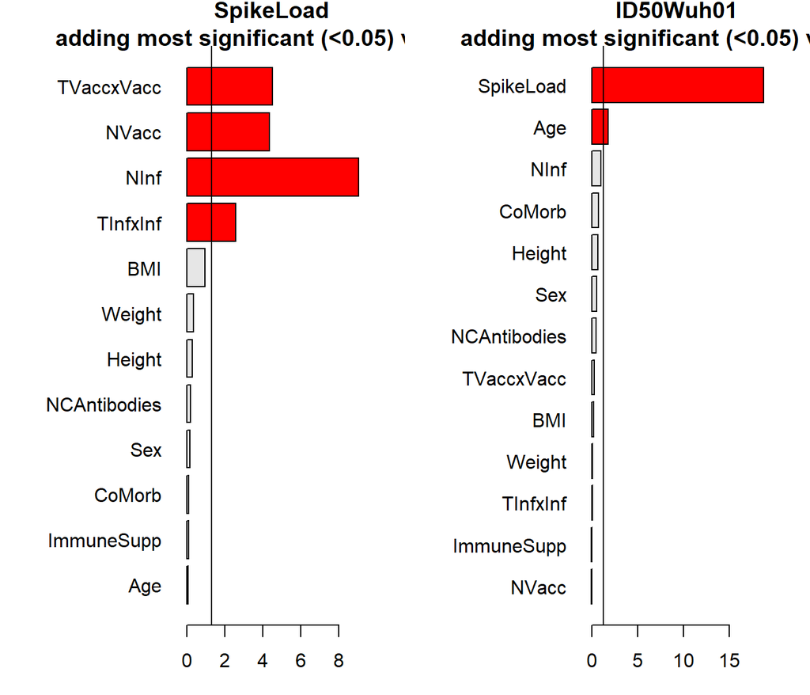

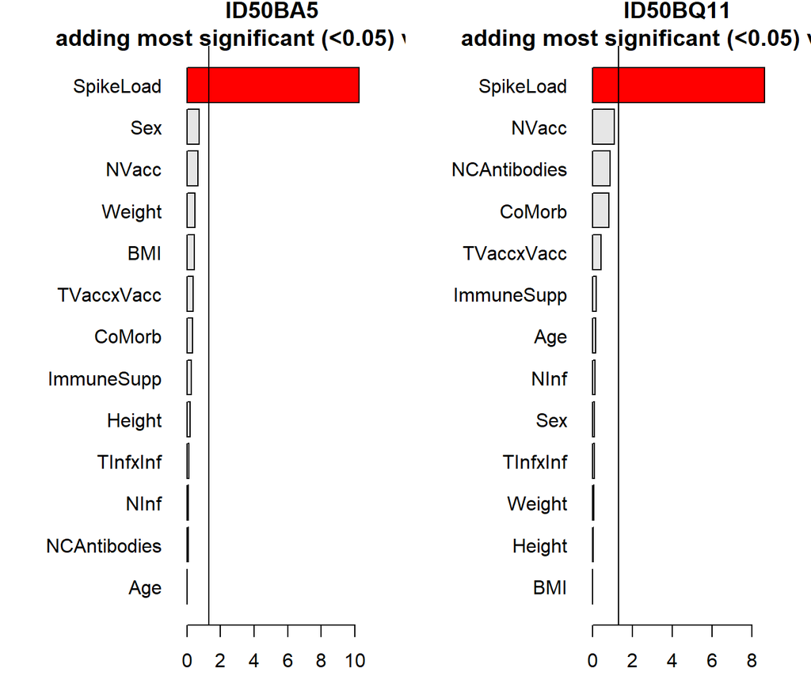

```r
par(mfrow=c(1,2))
responses <- c("SpikeLoad","ID50Wuh01","ID50BA5","ID50BQ11")
featureVals <- as.data.frame(matrix(NA,ncol(df),length(responses)))
rownames(featureVals) <- colnames(df)
colnames(featureVals) <- responses
counter <- 0
useVarsList <- list()
for (response in responses) {
  counter <- counter + 1
  dftmp <- df
  if (response=="SpikeLoad") {
    dftmp <- df[,which(!colnames(df) %in% c("ID50Wuh01","ID50BA5","ID50BQ11"))]
  }
  if (response=="ID50Wuh01") {
    dftmp <- df[,which(!colnames(df) %in% c("ID50BA5","ID50BQ11"))]
  }
  if (response=="ID50BA5") {
    dftmp <- df[,which(!colnames(df) %in% c("ID50Wuh01","ID50BQ11"))]
  }
  if (response=="ID50BQ11") {
    dftmp <- df[,which(!colnames(df) %in% c("ID50Wuh01","ID50BA5"))]
  }
  useVars <- response
  formula <- as.formula(paste0(response," ~ 1"))
  modBest <- lm(formula, data=dftmp)
  formula <- as.formula(paste0(response," ~ ."))
  fitinc <- NULL
  coltype <- NULL
  testVars <- colnames(dftmp)[colnames(dftmp)!=response]
  while(length(testVars)>0) {
    pvals <- numeric(length(colnames(dftmp)[which(colnames(dftmp) %in% testVars)]))
    for (i in testVars) {
      mod <- lm(formula, data=dftmp[,c(useVars,i)])
      pvals[which(i==colnames(dftmp)[which(colnames(dftmp) %in% testVars)])] <- (lmtest::lrtest(mod,modBest)[5])[2,]
    }
    fitinc <- c(fitinc,-log10(min(pvals)))
    names(fitinc)[length(fitinc)] <- colnames(dftmp)[which(colnames(dftmp) %in% testVars)][which.min(pvals)]
    if (min(pvals)<0.05) {
      useVars <- c(useVars,colnames(dftmp)[which(colnames(dftmp) %in% testVars)][which.min(pvals)])
      coltype <- c(coltype,1)
    } else {
      coltype <- c(coltype,2)
    }
    testVars <- testVars[which(!testVars %in% names(fitinc))]
    modBest <- lm(formula, data=dftmp[,useVars])
  }
  useVarsList[[response]] <- useVars
  par(mar=c(3,8,2,2))
  cols <- rep(rgb(1,0,0),sum(coltype==1))
  cols <- c(cols,rep(rgb(0.9,0.9,0.9),sum(coltype==2)))
  barplot(rev(fitinc),horiz=TRUE,las=1,col=rev(cols),
          xlab="-log10(p-value)",
          main=paste0(response,"\nadding most significant (<0.05) variable"))
  abline(v=-log10(0.05))
  featureVals[match(names(fitinc),rownames(featureVals)),counter] <- fitinc
}
```

# Show final models

In the final models we can scale the variable to make the coefficients comparable.

```r
models <- list()
count <- 1
counter <- 0
for (response in c("SpikeLoad","ID50Wuh01","ID50BA5","ID50BQ11")) {
  counter <- counter + 1
  formula <- as.formula(paste0(response," ~ ."))
  useVars <- useVarsList[[response]]
  dftmp <- df[,useVars]
  if (scaled) {
    dftmp[,unlist(lapply(dftmp,class))!="factor"] <- scale(dftmp[,unlist(lapply(dftmp,class))!="factor"])
  }
  mod <- lm(formula, data=dftmp)
  print(paste0(responses,c("","","","~Wuh01","","~Wuh01+BA5"))[counter])
  print(summary(mod))
  models[[counter]] <- mod
}
```

```
## [1] "SpikeLoad"
##
## Call:
## lm(formula = formula, data = dftmp)
##
## Residuals:
##      Min       1Q   Median       3Q      Max
## -0.31640 -0.08679  0.02113  0.09978  0.18829
##
## Coefficients:
##               Estimate Std. Error t value Pr(>|t|)
## (Intercept) -2.139e-17  3.355e-02   0.000   1.0000
## TVaccxVacc  -7.557e-01  3.471e-02 -21.773 9.19e-13 ***
## NVacc        5.462e-01  3.489e-02  15.652 1.06e-10 ***
## NInf         3.773e-01  3.536e-02  10.671 2.11e-08 ***
## TInfxInf    -1.038e-01  3.547e-02  -2.927   0.0104 *
## ---
## Signif. codes:  0 '***' 0.001 '**' 0.01 '*' 0.05 '.' 0.1 ' ' 1
##
## Residual standard error: 0.15 on 15 degrees of freedom
## Multiple R-squared:  0.9822, Adjusted R-squared:  0.9775
## F-statistic: 207.3 on 4 and 15 DF,  p-value: 6.239e-13
##
## [1] "ID50Wuh01"
##
## Call:
## lm(formula = formula, data = dftmp)
##
## Residuals:
##      Min       1Q   Median       3Q      Max
## -0.20766 -0.09415  0.01599  0.09415  0.15257
##
## Coefficients:
##              Estimate Std. Error t value Pr(>|t|)
## (Intercept) 1.295e-17  2.690e-02   0.000     1.00
## SpikeLoad   1.007e+00  2.842e-02  35.450   <2e-16 ***
## Age         6.731e-02  2.842e-02   2.369     0.03 *
## ---
## Signif. codes:  0 '***' 0.001 '**' 0.01 '*' 0.05 '.' 0.1 ' ' 1
##
```

[output cut: 28 more lines]

```
##
## Residuals:
##      Min       1Q   Median       3Q      Max
## -0.68918 -0.35932 -0.03765  0.29460  0.69656
##
## Coefficients:
##              Estimate Std. Error t value Pr(>|t|)
## (Intercept) 1.459e-17  9.412e-02   0.000        1
## SpikeLoad   9.122e-01  9.657e-02   9.447 2.13e-08 ***
## ---
## Signif. codes:  0 '***' 0.001 '**' 0.01 '*' 0.05 '.' 0.1 ' ' 1
##
## Residual standard error: 0.4209 on 18 degrees of freedom
## Multiple R-squared:  0.8322, Adjusted R-squared:  0.8228
## F-statistic: 89.24 on 1 and 18 DF,  p-value: 2.129e-08
```

# Bayesian network analysis

We run n bootstraps and summarize them by counting the edges. The final network is plotted with a cut off for edge fraction by m.

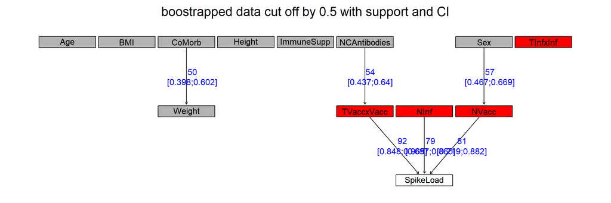

```
## .
```

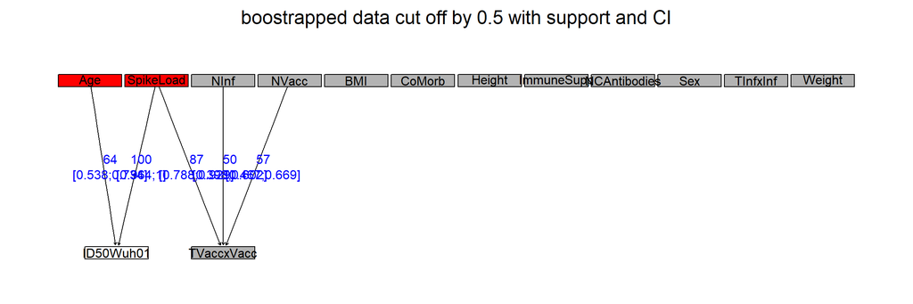

```
## .
```

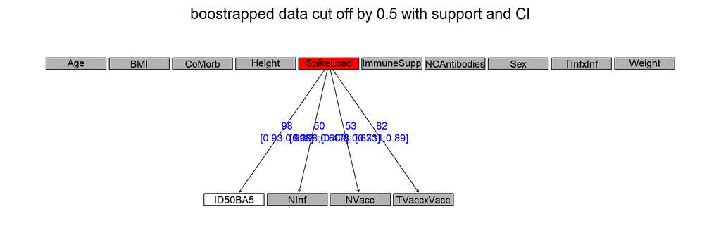

```
## .
```

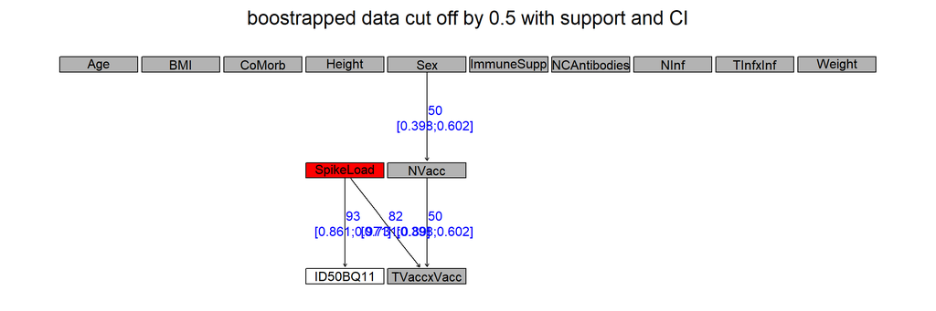

```
## .
```

```r
adj2dnf <- function(A) {
    dnf <- NULL
    for (i in seq_len(ncol(A))) {
        dnf <- c(dnf, rownames(A))
        for (j in seq_len(nrow(A))) {
            if (A[i, j] > 0) {
                dnf <- c(dnf, paste(colnames(A)[i], rownames(A)[j], sep = "="))
            }
            if (A[i, j] < 0) {
                dnf <- c(dnf, paste("!", colnames(A)[i], "=", rownames(A)[j],
                                    sep = ""))
            }
        }
    }
    dnf <- unique(dnf)
    return(dnf)
}
counter <- 0
for (response in c("SpikeLoad","ID50Wuh01","ID50BA5","ID50BQ11")) {
  counter <- counter + 1
  dftmp <- df
  if (response=="SpikeLoad") {
    dftmp <- df[,which(!colnames(df) %in% c("ID50Wuh01","ID50BA5","ID50BQ11"))]
  }
  if (response=="ID50Wuh01") {
    dftmp <- df[,which(!colnames(df) %in% c("ID50BA5","ID50BQ11"))]
  }
  if (response=="ID50BA5") {
    dftmp <- df[,which(!colnames(df) %in% c("ID50Wuh01","ID50BQ11"))]
  }
  if (response=="ID50BQ11") {
    dftmp <- df[,which(!colnames(df) %in% c("ID50Wuh01","ID50BA5"))]
  }
  useVars <- c(response,useVarsList[[response]])
  bl <- NULL
  for (i in 1:ncol(dftmp)) {
    bl <- rbind(bl,c(response,colnames(dftmp)[i]))
  }
  colnames(bl) <- c("from","to")
  bl <- as.data.frame(bl)
  bn <- hc(dftmp,blacklist=bl,restart=100,max.iter=1)
  bnorg <- mnem:::graph2adj(as.graphNEL(bn))
  bnbs <- bnorg*0
  doBs <- function(i,bnbs,df,bl) {
    bnbs <- hc(df[sample(1:nrow(df),nrow(df),replace=TRUE),],blacklist=bl,
               restart=100,max.iter=1000)
    return(bnbs)
  }
  filename <- paste0(responses[counter],"_cpdag_",docpdag,".rds")
  if (file.exists(filename) & redo==0) {
    bnbs <- readRDS(filename)
  } else {
    bnbs <- clusterApply(cl,1:n,doBs,bnbs,dftmp,bl)
    saveRDS(bnbs,filename)
  }
  bnbs <- lapply(bnbs,function(x,docpdag=0) {
    if (docpdag) x <- cpdag(x) # here cpdag
    y <- graph2adj(as.graphNEL(x))
  },docpdag=docpdag)
  bnbs <- do.call("abind",list(bnbs,along=3))
  bnbs <- apply(bnbs,c(1,2),sum)/n
  bnorg <- bnorg*bnbs
  nodecol <- list()
  for (i in 1:nrow(bnorg)) {
    nodecol[[ rownames(bnorg)[i]]] <- rgb(0.7,0.7,0.7)
    if (rownames(bnorg)[i] %in% useVars) nodecol[[ rownames(bnorg)[i]]] <- rgb(1,0,0)
  }
  nodecol[[response]] <- rgb(1,1,1)
  edgelabels <- character(length(bnbs))
  for (i in 1:length(bnbs)) {
    tmp <- binom.test(round(t(bnbs)[i]*n),n)
    edgelabels[i] <- paste0(round(t(bnbs)[i]*n),"\n",
                            "[",round(tmp$conf.int[1],3),";",round(tmp$conf.int[2],3),"]")
  }
  bnbscut <- bnbs
  bnbscut[bnbs<m] <- 0
  bnbscutdnf <- adj2dnf(bnbscut)
  plotDnf(adj2dnf(bnbscut),nodeshape="box",width=5,nodecol=nodecol,
          main="boostrapped data cut off by 0.5 with support and CI",
          edgelabel=c(rep("",length(bnbscutdnf)-length(grep("=",bnbscutdnf))),
                      edgelabels[which(as.vector(t(bnbscut))!=0)]),showall=FALSE)
  cat(".")
}
```

```r
stopCluster(cl)
```

```r
end <- Sys.time()
print("Runtime:")
```

```
## [1] "Runtime:"
```

```r
print(end-start)
```

```
## Time difference of 9.114224 secs
```